# ANOVA test for coerencia_tematica

Geiser C. Challco geiser@alumni.usp.br

- ANOVA: coerencia_tematica ~ time
  - Data Preparation
  - Summary Statistics
  - ANOVA Computation
  - PairWise Computation
- ANOVA: coerencia_tematica ~ time*gender + Error(id/time)
  - Data Preparation
    - Check assumptions: Identifying Outliers
    - Check assumptions: Normality Test
    - Summary Statistics
  - ANOVA Computation
  - ANOVA Computation after removing non.normal data
  - PairWise Computation
  - PairWise Computation after removing non.normal data
- ANOVA: coerencia_tematica ~ time*localizacao + Error(id/time)
  - Data Preparation
    - Check assumptions: Identifying Outliers
    - Check assumptions: Normality Test
    - Summary Statistics
  - ANOVA Computation
  - ANOVA Computation after removing non.normal data
  - PairWise Computation
  - PairWise Computation after removing non.normal data
- ANOVA: coerencia_tematica ~ time*regiao + Error(id/time)
  - Data Preparation
    - Check assumptions: Identifying Outliers
    - Check assumptions: Normality Test
    - Summary Statistics
  - ANOVA Computation
  - ANOVA Computation after removing non.normal data
  - PairWise Computation
  - PairWise Computation after removing non.normal data
- ANOVA: coerencia_tematica ~ time*porte + Error(id/time)
  - Data Preparation
    - Check assumptions: Identifying Outliers
    - Check assumptions: Normality Test
    - Summary Statistics
  - ANOVA Computation
  - ANOVA Computation after removing non.normal data
  - PairWise Computation
  - PairWise Computation after removing non.normal data

```r
dat <- read_excel("../data/data.xlsx", sheet = "alunos_ef59")

escolas <- read_excel("../data/data.xlsx", sheet = "escolas")
edat <- merge(dat, escolas, by = "cod_escola", all.x = T)
```

# ANOVA: coerencia_tematica ~ time

## Data Preparation

```r
data <- edat[,c("aluno_id","ciclo","coerencia_tematica")]
data <- data[data$ciclo %in% c("Primeiro Ciclo","Terceiro Ciclo"),]
data$ciclo <- factor(data$ciclo, c("Primeiro Ciclo","Terceiro Ciclo"))
data <- unique(data)

wdat <- spread(data, ciclo, coerencia_tematica)
wdat <- wdat[complete.cases(wdat),]
colnames(wdat) <- c("id","c1","c3")

ldat <- gather(wdat, key = time, value = coerencia_tematica, c1,c3) %>%
  convert_as_factor(id, time)
ldat <- rshinystatistics::remove_group_data(ldat, "coerencia_tematica", "time", n.limit = 30)
```

## Summary Statistics

```r
(sdat <- ldat %>% group_by(time) %>%
   get_summary_stats(coerencia_tematica, type = "mean_sd"))
```

```
## # A tibble: 2 × 5
##   time  variable               n  mean    sd
##   <fct> <fct>              <dbl> <dbl> <dbl>
## 1 c1    coerencia_tematica  3997  1.03 0.145
## 2 c3    coerencia_tematica  3997  1.02 0.164
```

| time | variable | n | mean | sd |
| --- | --- | --- | --- | --- |
| c1 | coerencia_tematica | 3997 | 1.027 | 0.145 |
| c3 | coerencia_tematica | 3997 | 1.023 | 0.164 |

## ANOVA Computation

```r
(res.aov <- anova_test(ldat, dv = coerencia_tematica, wid = id, within = time))
```

```
## ANOVA Table (type III tests)
##
##   Effect DFn  DFd     F     p p<.05      ges
## 1   time   1 3996 1.533 0.216       0.000188
```

## PairWise Computation

```r
(pwc <- ldat %>% emmeans_test(coerencia_tematica ~ time, detailed = T, p.adjust.method = "bonferroni"))
```

```
## # A tibble: 1 × 14
##   term  .y.   group1 group2 null.value estimate      se    df conf.low conf.high
## * <chr> <chr> <chr>  <chr>       <dbl>    <dbl>   <dbl> <dbl>    <dbl>     <dbl>
## 1 time  coer… c1     c3              0  0.00425 0.00347  7992 -0.00254    0.0110
## # ℹ 4 more variables: statistic <dbl>, p <dbl>, p.adj <dbl>, p.adj.signif <chr>
```

| term | .y. | group1 | group2 | null.value | estimate | se | df | conf.low | conf.high | statistic | p | p.adj | p.adj.signif |
| --- | --- | --- | --- | --- | --- | --- | --- | --- | --- | --- | --- | --- | --- |
| time | coerencia_tematica | c1 | c3 | 0 | 0.004 | 0.003 | 7992 | -0.003 | 0.011 | 1.227 | 0.22 | 0.22 | ns |

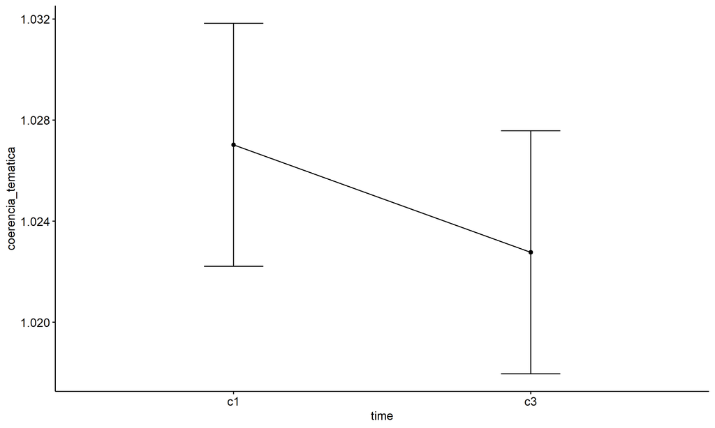

```r
pwc <- add_xy_position(pwc, x = "time", fun = "mean_se")
ggline(get_emmeans(pwc), x = "time", y = "emmean", ylab = "coerencia_tematica") +
  geom_errorbar(aes(ymin = conf.low, ymax = conf.high), width = 0.2) +
  stat_pvalue_manual(pwc, hide.ns = T, tip.length = F)
```

# ANOVA: coerencia_tematica ~ time*gender + Error(id/time)

## Data Preparation

```r
data <- edat[,c("aluno_id","gender","ciclo","coerencia_tematica")]
data <- data[data$ciclo %in% c("Primeiro Ciclo","Terceiro Ciclo"),]
data$ciclo <- factor(data$ciclo, c("Primeiro Ciclo","Terceiro Ciclo"))
data <- unique(data)

wdat <- spread(data, ciclo, coerencia_tematica)
wdat <- wdat[complete.cases(wdat),]
colnames(wdat) <- c("id","gender","c1","c3")

ldat <- gather(wdat, key = time, value = coerencia_tematica, c1,c3) %>%
  convert_as_factor(id, time)
ldat <- remove_group_data(ldat, "coerencia_tematica", c("time", "gender"), n.limit = 30)
ldat$gender <- factor(ldat$gender, sort(unique(ldat$gender)))
```

### Check assumptions: Identifying Outliers

```r
outliers <- identify_outliers(group_by(ldat, time, gender), coerencia_tematica)
(outliers <- outliers[outliers$is.extreme == T,])
```

```
## # A tibble: 232 × 6
##    gender time  id                   coerencia_tematica is.outlier is.extreme
##    <fct>  <fct> <fct>                             <dbl> <lgl>      <lgl>
##  1 Female c1    bHdxquaZ8XUwfwDJQQCh                1.5 TRUE       TRUE
##  2 Female c1    bkg0ArgSmyB4bWY1udDg                1.5 TRUE       TRUE
##  3 Female c1    cea1pI9NTEIE2VL4YEQj                1.5 TRUE       TRUE
##  4 Female c1    col2IMV8zL43sh3escHr                2   TRUE       TRUE
##  5 Female c1    D7Sm25aUnnDccJUkASMn                1.5 TRUE       TRUE
##  6 Female c1    EGPZ6xyZOiq8239Eo7wW                1.5 TRUE       TRUE
##  7 Female c1    fSeGvYUypBxsn9UAjp8k                1.5 TRUE       TRUE
##  8 Female c1    gcimPrBiERP821CKxZgH                2   TRUE       TRUE
##  9 Female c1    GgNJ908EEM577taK2rcX                1.5 TRUE       TRUE
## 10 Female c1    gLaZ7sLAnxfq8N5xhMue                1.5 TRUE       TRUE
## # ℹ 222 more rows
```

| gender | time | id | coerencia_tematica | is.outlier | is.extreme |
| --- | --- | --- | --- | --- | --- |
| Female | c1 | bHdxquaZ8XUwfwDJQQCh | 1.5 | TRUE | TRUE |
| Female | c1 | bkg0ArgSmyB4bWY1udDg | 1.5 | TRUE | TRUE |
| Female | c1 | cea1pI9NTEIE2VL4YEQj | 1.5 | TRUE | TRUE |
| Female | c1 | col2IMV8zL43sh3escHr | 2.0 | TRUE | TRUE |
| Female | c1 | D7Sm25aUnnDccJUkASMn | 1.5 | TRUE | TRUE |
| Female | c1 | EGPZ6xyZOiq8239Eo7wW | 1.5 | TRUE | TRUE |
| Female | c1 | fSeGvYUypBxsn9UAjp8k | 1.5 | TRUE | TRUE |
| Female | c1 | gcimPrBiERP821CKxZgH | 2.0 | TRUE | TRUE |
| Female | c1 | GgNJ908EEM577taK2rcX | 1.5 | TRUE | TRUE |
| Female | c1 | gLaZ7sLAnxfq8N5xhMue | 1.5 | TRUE | TRUE |
| Female | c1 | GlJgaFJ0J70UlvV58ITK | 1.5 | TRUE | TRUE |
| Female | c1 | GzCLghK9h0oymTsDyqeC | 2.0 | TRUE | TRUE |
| Female | c1 | H9sVgyqV5zY8N7Wi2LrS | 1.5 | TRUE | TRUE |
| Female | c1 | HApaalSboYPfShjYpktE | 1.5 | TRUE | TRUE |
| Female | c1 | HKtncnQSZNrOf3mzAxMX | 1.5 | TRUE | TRUE |
| Female | c1 | hlcGuhp2a574dv9jSgxz | 2.0 | TRUE | TRUE |
| Female | c1 | hOZgVXc5g4oTkIUTunFc | 1.5 | TRUE | TRUE |
| Female | c1 | IOzFe8bKlKLXC426Bw0D | 2.0 | TRUE | TRUE |
| Female | c1 | iZ0kcpTQuPIIYCjF9JGs | 1.5 | TRUE | TRUE |
| Female | c1 | jAQQeILs5PIvqA7uZVxS | 2.0 | TRUE | TRUE |
| Female | c1 | JB59hVGoMYyAt1jIteQL | 1.5 | TRUE | TRUE |
| Female | c1 | JIH35Vxqf0kBuusEQEBK | 1.5 | TRUE | TRUE |
| Female | c1 | jj8zEwuvHwF3DSeBVY0j | 1.5 | TRUE | TRUE |
| Female | c1 | JYwsDgGHGraSAFkJIot2 | 2.0 | TRUE | TRUE |
| Female | c1 | K7TMBHPukqALYKzvf7cx | 2.0 | TRUE | TRUE |
| Female | c1 | KJEZahfRRCiaTwQuvtmh | 2.0 | TRUE | TRUE |
| Female | c1 | lA2MxCV3knz4ZwIQLhxL | 1.5 | TRUE | TRUE |
| Female | c1 | LAE7FZYedalWpiev4Efs | 2.0 | TRUE | TRUE |
| Female | c1 | li1Oo6JocIlOKbSbGGPL | 2.0 | TRUE | TRUE |
| Female | c1 | lkBCRumBZ1wjJR3vXPdU | 2.0 | TRUE | TRUE |

[output cut: 202 more lines]

### Check assumptions: Normality Test

```r
(normality.df <- normality.test.per.groups(ldat, "coerencia_tematica", c("time", "gender")))
```

```
##                  var           variable time gender    n skewness  kurtosis
## 1 coerencia_tematica coerencia_tematica   c1 Female 1880 0.000000   0.00000
## 2 coerencia_tematica coerencia_tematica   c1   Male 1927 7.556902  73.66179
## 3 coerencia_tematica coerencia_tematica   c3 Female 1880 8.924368 100.89089
## 4 coerencia_tematica coerencia_tematica   c3   Male 1927 0.000000   0.00000
##   symmetry statistic     method p p.signif normality
## 1 few data        NA       <NA> 1     <NA>        NO
## 2       NO  2586.372 D'Agostino 0     ****         -
## 3       NO  2786.534 D'Agostino 0     ****         -
## 4 few data        NA       <NA> 1     <NA>        NO
```

| var | variable | time | gender | n | skewness | kurtosis | symmetry | statistic | method | p | p.signif | normality |
| --- | --- | --- | --- | --- | --- | --- | --- | --- | --- | --- | --- | --- |
| coerencia_tematica | coerencia_tematica | c1 | Female | 1880 | 0.000 | 0.000 | few data | NA | NA | 1 | NA | NO |
| coerencia_tematica | coerencia_tematica | c1 | Male | 1927 | 7.557 | 73.662 | NO | 2586.372 | D’Agostino | 0 | **** | - |
| coerencia_tematica | coerencia_tematica | c3 | Female | 1880 | 8.924 | 100.891 | NO | 2786.534 | D’Agostino | 0 | **** | - |
| coerencia_tematica | coerencia_tematica | c3 | Male | 1927 | 0.000 | 0.000 | few data | NA | NA | 1 | NA | NO |

```r
(non.ids <- unique(do.call(
  c, lapply(which(normality.df$normality == 'NO'), FUN = function(i) {
  idx = which(ldat$time == normality.df$time[i] &
                ldat$gender == normality.df$gender[i])
  getNonNormal(ldat$"coerencia_tematica"[idx], ldat$id[idx])
}))))
```

```r
if (length(non.ids) > 0)
  ldat2 <- ldat[!ldat$id %in% non.ids,]
```

### Summary Statistics

```r
(sdat <- ldat %>% group_by(time, gender) %>%
   get_summary_stats(coerencia_tematica, type = "mean_sd"))
```

```
## # A tibble: 4 × 6
##   gender time  variable               n  mean    sd
##   <fct>  <fct> <fct>              <dbl> <dbl> <dbl>
## 1 Female c1    coerencia_tematica  1880  1.03 0.148
## 2 Male   c1    coerencia_tematica  1927  1.02 0.133
## 3 Female c3    coerencia_tematica  1880  1.03 0.198
## 4 Male   c3    coerencia_tematica  1927  1.02 0.122
```

| gender | time | variable | n | mean | sd |
| --- | --- | --- | --- | --- | --- |
| Female | c1 | coerencia_tematica | 1880 | 1.030 | 0.148 |
| Male | c1 | coerencia_tematica | 1927 | 1.023 | 0.133 |
| Female | c3 | coerencia_tematica | 1880 | 1.029 | 0.198 |
| Male | c3 | coerencia_tematica | 1927 | 1.016 | 0.122 |

```r
if (length(non.ids) > 0)
  (sdat <- ldat2 %>% group_by(time, gender) %>%
      get_summary_stats(coerencia_tematica, type = "mean_sd"))
```

| gender | time | variable | n | mean | sd |
| --- | --- | --- | --- | --- | --- |
| Female | c1 | coerencia_tematica | 1880 | 1.030 | 0.148 |
| Male | c1 | coerencia_tematica | 1927 | 1.023 | 0.133 |
| Female | c3 | coerencia_tematica | 1880 | 1.029 | 0.198 |
| Male | c3 | coerencia_tematica | 1927 | 1.016 | 0.122 |

## ANOVA Computation

```r
(res.aov <- anova_test(ldat, dv = coerencia_tematica, wid = id, between = gender, within = time))
```

```
## ANOVA Table (type III tests)
##
##        Effect DFn  DFd     F     p p<.05      ges
## 1      gender   1 3805 8.402 0.004     * 0.001000
## 2        time   1 3805 1.173 0.279       0.000152
## 3 gender:time   1 3805 1.013 0.314       0.000132
```

## ANOVA Computation after removing non.normal data

```r
if (length(non.ids) > 0)
  (res.aov2 <- anova_test(ldat2, dv = coerencia_tematica, wid = id, between = gender , within = time))
```

## PairWise Computation

```r
(pwc <- ldat %>% group_by(time) %>%
   emmeans_test(coerencia_tematica ~ gender, detailed = T, p.adjust.method = "bonferroni"))
```

```
## # A tibble: 2 × 15
##   time  term   .y.      group1 group2 null.value estimate      se    df conf.low
## * <fct> <chr>  <chr>    <chr>  <chr>       <dbl>    <dbl>   <dbl> <dbl>    <dbl>
## 1 c1    gender coerenc… Female Male            0  0.00669 0.00494  7610 -0.00300
## 2 c3    gender coerenc… Female Male            0  0.0137  0.00494  7610  0.00399
## # ℹ 5 more variables: conf.high <dbl>, statistic <dbl>, p <dbl>, p.adj <dbl>,
## #   p.adj.signif <chr>
```

| time | term | .y. | group1 | group2 | null.value | estimate | se | df | conf.low | conf.high | statistic | p | p.adj | p.adj.signif |
| --- | --- | --- | --- | --- | --- | --- | --- | --- | --- | --- | --- | --- | --- | --- |
| c1 | gender | coerencia_tematica | Female | Male | 0 | 0.007 | 0.005 | 7610 | -0.003 | 0.016 | 1.353 | 0.176 | 0.176 | ns |
| c3 | gender | coerencia_tematica | Female | Male | 0 | 0.014 | 0.005 | 7610 | 0.004 | 0.023 | 2.768 | 0.006 | 0.006 | ** |

```r
(emms <- get_emmeans(pwc))
```

```
## # A tibble: 4 × 8
##   time  gender emmean      se    df conf.low conf.high method
##   <fct> <fct>   <dbl>   <dbl> <dbl>    <dbl>     <dbl> <chr>
## 1 c1    Female   1.03 0.00352  7610     1.02      1.04 Emmeans test
## 2 c1    Male     1.02 0.00347  7610     1.02      1.03 Emmeans test
## 3 c3    Female   1.03 0.00352  7610     1.02      1.04 Emmeans test
## 4 c3    Male     1.02 0.00347  7610     1.01      1.02 Emmeans test
```

| time | gender | emmean | se | df | conf.low | conf.high | method |
| --- | --- | --- | --- | --- | --- | --- | --- |
| c1 | Female | 1.030 | 0.004 | 7610 | 1.023 | 1.036 | Emmeans test |
| c1 | Male | 1.023 | 0.003 | 7610 | 1.016 | 1.030 | Emmeans test |
| c3 | Female | 1.029 | 0.004 | 7610 | 1.022 | 1.036 | Emmeans test |
| c3 | Male | 1.016 | 0.003 | 7610 | 1.009 | 1.022 | Emmeans test |

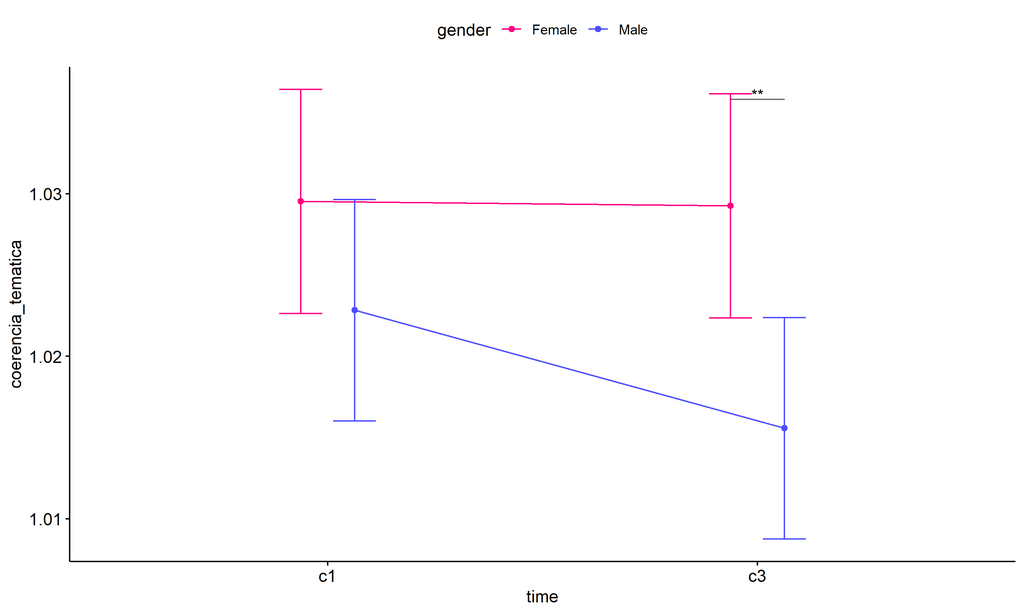

```r
pwc <- add_xy_position(pwc, x = "time", fun = "mean_se", dodge = 0.25)
pd <- position_dodge(width = 0.25)
ggline(emms, x = "time", y = "emmean", color = "gender",
       palette = c("#FF007F","#4D4DFF"),
       position = pd, ylab = "coerencia_tematica") +
  geom_errorbar(aes(ymin = conf.low, ymax = conf.high, color = gender),
                position = pd, width = 0.2) +
  stat_pvalue_manual(pwc, hide.ns = T, tip.length = F, linetype = 1)
```

```r
(pwc <- ldat %>% group_by(gender) %>%
    emmeans_test(coerencia_tematica ~ time, detailed = T, p.adjust.method = "bonferroni"))
```

```
## # A tibble: 2 × 15
##   gender term  .y.      group1 group2 null.value estimate      se    df conf.low
## * <fct>  <chr> <chr>    <chr>  <chr>       <dbl>    <dbl>   <dbl> <dbl>    <dbl>
## 1 Female time  coerenc… c1     c3              0 0.000266 0.00497  7610 -0.00949
## 2 Male   time  coerenc… c1     c3              0 0.00727  0.00491  7610 -0.00237
## # ℹ 5 more variables: conf.high <dbl>, statistic <dbl>, p <dbl>, p.adj <dbl>,
## #   p.adj.signif <chr>
```

| gender | term | .y. | group1 | group2 | null.value | estimate | se | df | conf.low | conf.high | statistic | p | p.adj | p.adj.signif |
| --- | --- | --- | --- | --- | --- | --- | --- | --- | --- | --- | --- | --- | --- | --- |
| Female | time | coerencia_tematica | c1 | c3 | 0 | 0.000 | 0.005 | 7610 | -0.009 | 0.010 | 0.053 | 0.957 | 0.957 | ns |
| Male | time | coerencia_tematica | c1 | c3 | 0 | 0.007 | 0.005 | 7610 | -0.002 | 0.017 | 1.479 | 0.139 | 0.139 | ns |

```r
(emms <- get_emmeans(pwc))
```

```
## # A tibble: 4 × 8
##   gender time  emmean      se    df conf.low conf.high method
##   <fct>  <fct>  <dbl>   <dbl> <dbl>    <dbl>     <dbl> <chr>
## 1 Female c1      1.03 0.00352  7610     1.02      1.04 Emmeans test
## 2 Female c3      1.03 0.00352  7610     1.02      1.04 Emmeans test
## 3 Male   c1      1.02 0.00347  7610     1.02      1.03 Emmeans test
## 4 Male   c3      1.02 0.00347  7610     1.01      1.02 Emmeans test
```

| gender | time | emmean | se | df | conf.low | conf.high | method |
| --- | --- | --- | --- | --- | --- | --- | --- |
| Female | c1 | 1.030 | 0.004 | 7610 | 1.023 | 1.036 | Emmeans test |
| Female | c3 | 1.029 | 0.004 | 7610 | 1.022 | 1.036 | Emmeans test |
| Male | c1 | 1.023 | 0.003 | 7610 | 1.016 | 1.030 | Emmeans test |
| Male | c3 | 1.016 | 0.003 | 7610 | 1.009 | 1.022 | Emmeans test |

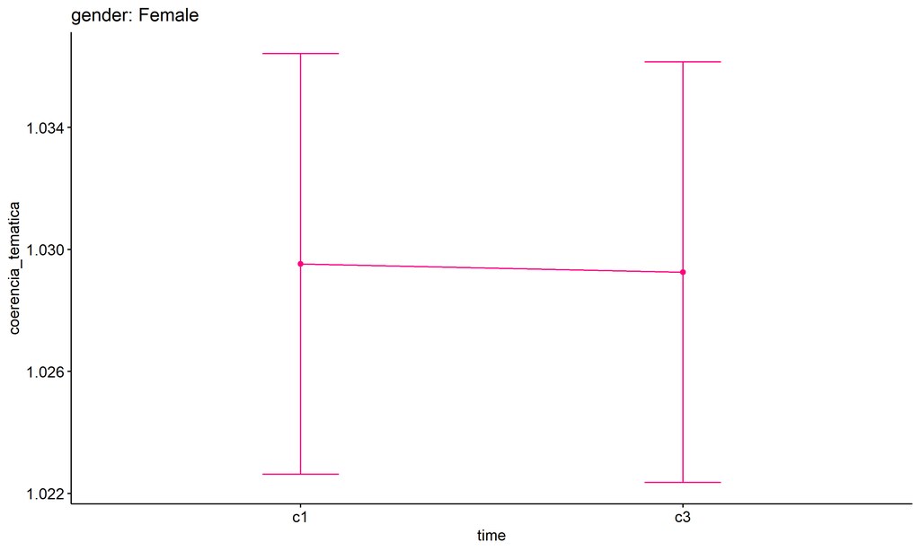

```r
emms.gg <- emms[which(emms$gender == "Female"),]
if (nrow(emms.gg) > 0)
  ggline(emms.gg, x = "time", y = "emmean", color = "#FF007F", ylab = "coerencia_tematica") +
    geom_errorbar(aes(ymin = conf.low, ymax = conf.high),
                  width = 0.2, color = "#FF007F") +
    stat_pvalue_manual(
      add_xy_position(pwc[which(pwc$gender == "Female"),],
                      x = "time", fun = "mean_se"),
      hide.ns = T, color = "#FF007F", tip.length = F) +
    labs(title = "gender: Female")+
    theme(legend.text = element_blank())
```

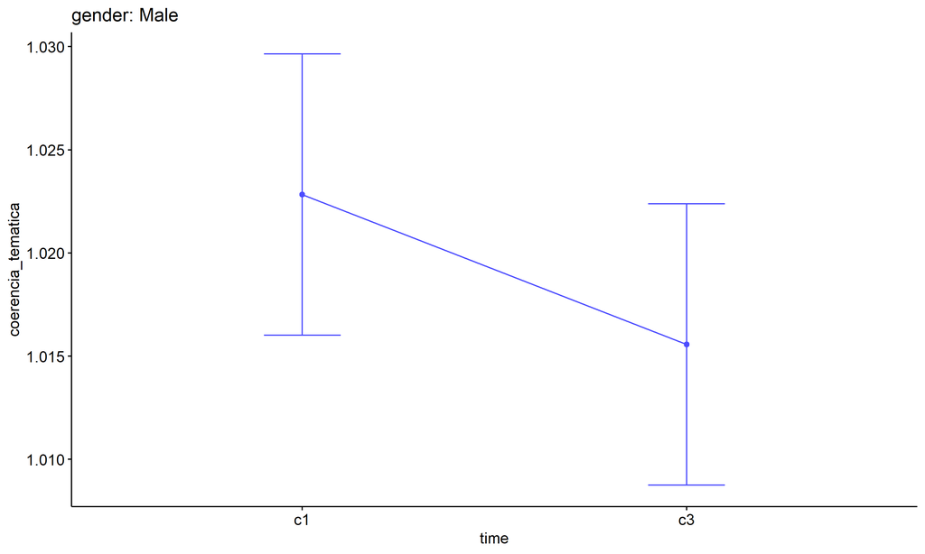

```r
emms.gg <- emms[which(emms$gender == "Male"),]
if (nrow(emms.gg) > 0)
  ggline(emms.gg, x = "time", y = "emmean", color = "#4D4DFF", ylab = "coerencia_tematica") +
    geom_errorbar(aes(ymin = conf.low, ymax = conf.high),
                  width = 0.2, color = "#4D4DFF") +
    stat_pvalue_manual(
      add_xy_position(pwc[which(pwc$gender == "Male"),],
                      x = "time", fun = "mean_se"),
      hide.ns = T, color = "#4D4DFF", tip.length = F) +
    labs(title = "gender: Male")+
    theme(legend.text = element_blank())
```

## PairWise Computation after removing non.normal data

```r
if (length(non.ids) > 0)
  (pwc2 <- ldat2 %>% group_by(time) %>%
     emmeans_test(coerencia_tematica ~ gender, detailed = T, p.adjust.method = "bonferroni"))
```

```r
if (length(non.ids) > 0)
  (emms2 <- get_emmeans(pwc2))
```

```r
if (length(non.ids) > 0) {
  pwc2 <- add_xy_position(pwc2, x = "time", fun = "mean_se", dodge = 0.25)
  pd2 <- position_dodge(width = 0.25)

  ggline(emms2, x = "time", y = "emmean", color = "gender",
         palette = c("#FF007F","#4D4DFF"),
         position = pd, ylab = "coerencia_tematica") +
    geom_errorbar(aes(ymin = conf.low, ymax = conf.high, color = gender),
                position = pd, width = 0.2) +
    stat_pvalue_manual(pwc2, hide.ns = T, tip.length = F, linetype = 1)
}
```

```r
if (length(non.ids) > 0)
  (pwc2 <- ldat2 %>% group_by(gender) %>%
     emmeans_test(coerencia_tematica ~ time, detailed = T, p.adjust.method = "bonferroni"))
```

```r
if (length(non.ids) > 0)
  (emms2 <- get_emmeans(pwc2))
```

```r
if (length(non.ids) > 0) {
  emms.gg <- emms2[which(emms2$gender == "Female"),]
  if (nrow(emms.gg) > 0)
    ggline(emms.gg, x = "time", y = "emmean", color = "#FF007F", ylab = "coerencia_tematica") +
    geom_errorbar(aes(ymin = conf.low, ymax = conf.high),
                  width = 0.2, color = "#FF007F") +
    stat_pvalue_manual(
      add_xy_position(pwc[which(pwc$gender == "Female"),],
                      x = "time", fun = "mean_se"),
      hide.ns = T, color = "#FF007F", tip.length = F) +
    labs(title = "gender: Female") +
    theme(legend.text = element_blank())
}
```

```r
if (length(non.ids) > 0) {
  emms.gg <- emms2[which(emms2$gender == "Male"),]
  if (nrow(emms.gg) > 0)
    ggline(emms.gg, x = "time", y = "emmean", color = "#4D4DFF", ylab = "coerencia_tematica") +
    geom_errorbar(aes(ymin = conf.low, ymax = conf.high),
                  width = 0.2, color = "#4D4DFF") +
    stat_pvalue_manual(
      add_xy_position(pwc[which(pwc$gender == "Male"),],
                      x = "time", fun = "mean_se"),
      hide.ns = T, color = "#4D4DFF", tip.length = F) +
    labs(title = "gender: Male") +
    theme(legend.text = element_blank())
}
```

# ANOVA: coerencia_tematica ~ time*localizacao + Error(id/time)

## Data Preparation

```r
data <- edat[,c("aluno_id","localizacao","ciclo","coerencia_tematica")]
data <- data[data$ciclo %in% c("Primeiro Ciclo","Terceiro Ciclo"),]
data$ciclo <- factor(data$ciclo, c("Primeiro Ciclo","Terceiro Ciclo"))
data <- unique(data)

wdat <- spread(data, ciclo, coerencia_tematica)
wdat <- wdat[complete.cases(wdat),]
colnames(wdat) <- c("id","localizacao","c1","c3")

ldat <- gather(wdat, key = time, value = coerencia_tematica, c1,c3) %>%
  convert_as_factor(id, time)
ldat <- remove_group_data(ldat, "coerencia_tematica", c("time", "localizacao"), n.limit = 30)
ldat$localizacao <- factor(ldat$localizacao, sort(unique(ldat$localizacao)))
```

### Check assumptions: Identifying Outliers

```r
outliers <- identify_outliers(group_by(ldat, time, localizacao), coerencia_tematica)
(outliers <- outliers[outliers$is.extreme == T,])
```

```
## # A tibble: 248 × 6
##    localizacao time  id                 coerencia_tematica is.outlier is.extreme
##    <fct>       <fct> <fct>                           <dbl> <lgl>      <lgl>
##  1 Rural       c1    A9RUkyTkFXi5lp8ry…                2   TRUE       TRUE
##  2 Rural       c1    bkg0ArgSmyB4bWY1u…                1.5 TRUE       TRUE
##  3 Rural       c1    eDDthAP6dWERQriBP…                1.5 TRUE       TRUE
##  4 Rural       c1    gDRGUsOBQicWdVKdq…                1.5 TRUE       TRUE
##  5 Rural       c1    gLaZ7sLAnxfq8N5xh…                1.5 TRUE       TRUE
##  6 Rural       c1    HbX9wIM2m5EDRXj1c…                2   TRUE       TRUE
##  7 Rural       c1    hOZgVXc5g4oTkIUTu…                1.5 TRUE       TRUE
##  8 Rural       c1    HZkpVVbxvFMJQ62DB…                1.5 TRUE       TRUE
##  9 Rural       c1    i3ImRhfefZZ4n4XQG…                1.5 TRUE       TRUE
## 10 Rural       c1    JB59hVGoMYyAt1jIt…                1.5 TRUE       TRUE
## # ℹ 238 more rows
```

| localizacao | time | id | coerencia_tematica | is.outlier | is.extreme |
| --- | --- | --- | --- | --- | --- |
| Rural | c1 | A9RUkyTkFXi5lp8ryfZ7 | 2.0 | TRUE | TRUE |
| Rural | c1 | bkg0ArgSmyB4bWY1udDg | 1.5 | TRUE | TRUE |
| Rural | c1 | eDDthAP6dWERQriBPjXp | 1.5 | TRUE | TRUE |
| Rural | c1 | gDRGUsOBQicWdVKdqivA | 1.5 | TRUE | TRUE |
| Rural | c1 | gLaZ7sLAnxfq8N5xhMue | 1.5 | TRUE | TRUE |
| Rural | c1 | HbX9wIM2m5EDRXj1cGIG | 2.0 | TRUE | TRUE |
| Rural | c1 | hOZgVXc5g4oTkIUTunFc | 1.5 | TRUE | TRUE |
| Rural | c1 | HZkpVVbxvFMJQ62DBzoy | 1.5 | TRUE | TRUE |
| Rural | c1 | i3ImRhfefZZ4n4XQG3YG | 1.5 | TRUE | TRUE |
| Rural | c1 | JB59hVGoMYyAt1jIteQL | 1.5 | TRUE | TRUE |
| Rural | c1 | li1Oo6JocIlOKbSbGGPL | 2.0 | TRUE | TRUE |
| Rural | c1 | N8PMFQN9SOo3eRxv300R | 2.0 | TRUE | TRUE |
| Rural | c1 | NU88StbmGlGjaAXdZqqV | 1.5 | TRUE | TRUE |
| Rural | c1 | OJQJXGYqknL5VsaAN7Pa | 2.0 | TRUE | TRUE |
| Rural | c1 | OLOxlfCyza2ZKfGPA2pY | 1.5 | TRUE | TRUE |
| Rural | c1 | OYUbfGbyPB3JB9v6ALC4 | 1.5 | TRUE | TRUE |
| Rural | c1 | R2fC8QvLjzoBWt4Nmofb | 1.5 | TRUE | TRUE |
| Rural | c1 | RUiarbHlHC1Y2yDMAWVN | 1.5 | TRUE | TRUE |
| Rural | c1 | Ry2i88KcujFgfmcnR7XF | 1.5 | TRUE | TRUE |
| Rural | c1 | sp0Fux6Pmq2Ch2Ef8fAU | 1.5 | TRUE | TRUE |
| Rural | c1 | stYStwHWnO2cdf2af8bX | 1.5 | TRUE | TRUE |
| Rural | c1 | TPobDcLYzJFEXhqR3YD0 | 2.0 | TRUE | TRUE |
| Rural | c1 | TQpscKy5rHe0PmM5tF7j | 1.5 | TRUE | TRUE |
| Rural | c1 | TsFOQEsfu5hqo3DHq7mY | 1.5 | TRUE | TRUE |
| Rural | c1 | Ucc4PNrqBenHHXkHEewv | 2.0 | TRUE | TRUE |
| Rural | c1 | UXyyStkdvsH6ileVMrou | 1.5 | TRUE | TRUE |
| Rural | c1 | v8aquDX1Ryy24YbAe13O | 1.5 | TRUE | TRUE |
| Rural | c1 | V9jk8HEEzl4Qae6emMYV | 2.0 | TRUE | TRUE |
| Rural | c1 | vBlaXuZ8ZY8rKwmDYaQ6 | 1.5 | TRUE | TRUE |
| Rural | c1 | vcFSZlrZreRXDfzNZtRb | 1.5 | TRUE | TRUE |

[output cut: 218 more lines]

### Check assumptions: Normality Test

```r
(normality.df <- normality.test.per.groups(ldat, "coerencia_tematica", c("time", "localizacao")))
```

```
##                  var           variable time localizacao    n skewness
## 1 coerencia_tematica coerencia_tematica   c1       Rural  683 0.000000
## 2 coerencia_tematica coerencia_tematica   c1      Urbana 3314 6.818175
## 3 coerencia_tematica coerencia_tematica   c3       Rural  683 9.076312
## 4 coerencia_tematica coerencia_tematica   c3      Urbana 3314 9.067625
##    kurtosis symmetry statistic     method p p.signif normality
## 1   0.00000 few data        NA       <NA> 1     <NA>        NO
## 2  56.29111       NO  4109.373 D'Agostino 0     ****         -
## 3 102.88623       NO  1062.296 D'Agostino 0     ****         -
## 4 109.10357       NO  4920.882 D'Agostino 0     ****         -
```

| var | variable | time | localizacao | n | skewness | kurtosis | symmetry | statistic | method | p | p.signif | normality |
| --- | --- | --- | --- | --- | --- | --- | --- | --- | --- | --- | --- | --- |
| coerencia_tematica | coerencia_tematica | c1 | Rural | 683 | 0.000 | 0.000 | few data | NA | NA | 1 | NA | NO |
| coerencia_tematica | coerencia_tematica | c1 | Urbana | 3314 | 6.818 | 56.291 | NO | 4109.373 | D’Agostino | 0 | **** | - |
| coerencia_tematica | coerencia_tematica | c3 | Rural | 683 | 9.076 | 102.886 | NO | 1062.296 | D’Agostino | 0 | **** | - |
| coerencia_tematica | coerencia_tematica | c3 | Urbana | 3314 | 9.068 | 109.104 | NO | 4920.882 | D’Agostino | 0 | **** | - |

```r
(non.ids <- unique(do.call(
  c, lapply(which(normality.df$normality == 'NO'), FUN = function(i) {
  idx = which(ldat$time == normality.df$time[i] &
                ldat$localizacao == normality.df$localizacao[i])
  getNonNormal(ldat$"coerencia_tematica"[idx], ldat$id[idx])
}))))
```

```r
if (length(non.ids) > 0)
  ldat2 <- ldat[!ldat$id %in% non.ids,]
```

### Summary Statistics

```r
(sdat <- ldat %>% group_by(time, localizacao) %>%
   get_summary_stats(coerencia_tematica, type = "mean_sd"))
```

```
## # A tibble: 4 × 6
##   localizacao time  variable               n  mean    sd
##   <fct>       <fct> <fct>              <dbl> <dbl> <dbl>
## 1 Rural       c1    coerencia_tematica   683  1.03 0.149
## 2 Urbana      c1    coerencia_tematica  3314  1.03 0.144
## 3 Rural       c3    coerencia_tematica   683  1.03 0.195
## 4 Urbana      c3    coerencia_tematica  3314  1.02 0.157
```

| localizacao | time | variable | n | mean | sd |
| --- | --- | --- | --- | --- | --- |
| Rural | c1 | coerencia_tematica | 683 | 1.034 | 0.149 |
| Urbana | c1 | coerencia_tematica | 3314 | 1.026 | 0.144 |
| Rural | c3 | coerencia_tematica | 683 | 1.028 | 0.195 |
| Urbana | c3 | coerencia_tematica | 3314 | 1.022 | 0.157 |

```r
if (length(non.ids) > 0)
  (sdat <- ldat2 %>% group_by(time, localizacao) %>%
      get_summary_stats(coerencia_tematica, type = "mean_sd"))
```

| localizacao | time | variable | n | mean | sd |
| --- | --- | --- | --- | --- | --- |
| Rural | c1 | coerencia_tematica | 683 | 1.034 | 0.149 |
| Urbana | c1 | coerencia_tematica | 3314 | 1.026 | 0.144 |
| Rural | c3 | coerencia_tematica | 683 | 1.028 | 0.195 |
| Urbana | c3 | coerencia_tematica | 3314 | 1.022 | 0.157 |

## ANOVA Computation

```r
(res.aov <- anova_test(ldat, dv = coerencia_tematica, wid = id, between = localizacao, within = time))
```

```
## ANOVA Table (type III tests)
##
##             Effect DFn  DFd     F     p p<.05      ges
## 1      localizacao   1 3995 2.307 0.129       2.94e-04
## 2             time   1 3995 1.148 0.284       1.41e-04
## 3 localizacao:time   1 3995 0.045 0.832       5.52e-06
```

## ANOVA Computation after removing non.normal data

```r
if (length(non.ids) > 0)
  (res.aov2 <- anova_test(ldat2, dv = coerencia_tematica, wid = id, between = localizacao , within = time))
```

## PairWise Computation

```r
(pwc <- ldat %>% group_by(time) %>%
   emmeans_test(coerencia_tematica ~ localizacao, detailed = T, p.adjust.method = "bonferroni"))
```

```
## # A tibble: 2 × 15
##   time  term      .y.   group1 group2 null.value estimate      se    df conf.low
## * <fct> <chr>     <chr> <chr>  <chr>       <dbl>    <dbl>   <dbl> <dbl>    <dbl>
## 1 c1    localiza… coer… Rural  Urbana          0  0.00803 0.00651  7990 -0.00474
## 2 c3    localiza… coer… Rural  Urbana          0  0.00609 0.00651  7990 -0.00668
## # ℹ 5 more variables: conf.high <dbl>, statistic <dbl>, p <dbl>, p.adj <dbl>,
## #   p.adj.signif <chr>
```

| time | term | .y. | group1 | group2 | null.value | estimate | se | df | conf.low | conf.high | statistic | p | p.adj | p.adj.signif |
| --- | --- | --- | --- | --- | --- | --- | --- | --- | --- | --- | --- | --- | --- | --- |
| c1 | localizacao | coerencia_tematica | Rural | Urbana | 0 | 0.008 | 0.007 | 7990 | -0.005 | 0.021 | 1.232 | 0.218 | 0.218 | ns |
| c3 | localizacao | coerencia_tematica | Rural | Urbana | 0 | 0.006 | 0.007 | 7990 | -0.007 | 0.019 | 0.935 | 0.350 | 0.350 | ns |

```r
(emms <- get_emmeans(pwc))
```

```
## # A tibble: 4 × 8
##   time  localizacao emmean      se    df conf.low conf.high method
##   <fct> <fct>        <dbl>   <dbl> <dbl>    <dbl>     <dbl> <chr>
## 1 c1    Rural         1.03 0.00593  7990     1.02      1.05 Emmeans test
## 2 c1    Urbana        1.03 0.00269  7990     1.02      1.03 Emmeans test
## 3 c3    Rural         1.03 0.00593  7990     1.02      1.04 Emmeans test
## 4 c3    Urbana        1.02 0.00269  7990     1.02      1.03 Emmeans test
```

| time | localizacao | emmean | se | df | conf.low | conf.high | method |
| --- | --- | --- | --- | --- | --- | --- | --- |
| c1 | Rural | 1.034 | 0.006 | 7990 | 1.022 | 1.045 | Emmeans test |
| c1 | Urbana | 1.026 | 0.003 | 7990 | 1.020 | 1.031 | Emmeans test |
| c3 | Rural | 1.028 | 0.006 | 7990 | 1.016 | 1.039 | Emmeans test |
| c3 | Urbana | 1.022 | 0.003 | 7990 | 1.016 | 1.027 | Emmeans test |

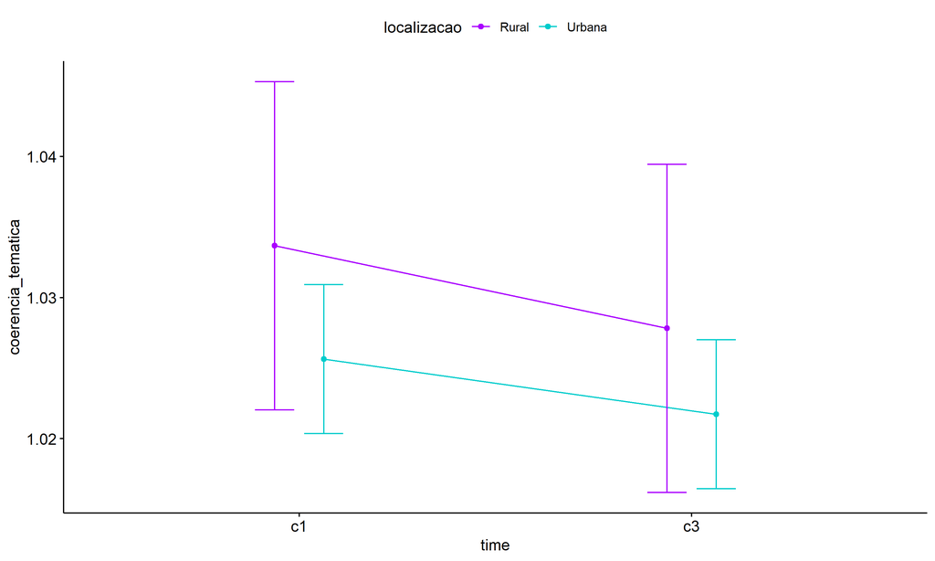

```r
pwc <- add_xy_position(pwc, x = "time", fun = "mean_se", dodge = 0.25)
pd <- position_dodge(width = 0.25)
ggline(emms, x = "time", y = "emmean", color = "localizacao",
       palette = c("#AA00FF","#00CCCC"),
       position = pd, ylab = "coerencia_tematica") +
  geom_errorbar(aes(ymin = conf.low, ymax = conf.high, color = localizacao),
                position = pd, width = 0.2) +
  stat_pvalue_manual(pwc, hide.ns = T, tip.length = F, linetype = 1)
```

```r
(pwc <- ldat %>% group_by(localizacao) %>%
    emmeans_test(coerencia_tematica ~ time, detailed = T, p.adjust.method = "bonferroni"))
```

```
## # A tibble: 2 × 15
##   localizacao term  .y.          group1 group2 null.value estimate      se    df
## * <fct>       <chr> <chr>        <chr>  <chr>       <dbl>    <dbl>   <dbl> <dbl>
## 1 Rural       time  coerencia_t… c1     c3              0  0.00586 0.00839  7990
## 2 Urbana      time  coerencia_t… c1     c3              0  0.00392 0.00381  7990
## # ℹ 6 more variables: conf.low <dbl>, conf.high <dbl>, statistic <dbl>,
## #   p <dbl>, p.adj <dbl>, p.adj.signif <chr>
```

| localizacao | term | .y. | group1 | group2 | null.value | estimate | se | df | conf.low | conf.high | statistic | p | p.adj | p.adj.signif |
| --- | --- | --- | --- | --- | --- | --- | --- | --- | --- | --- | --- | --- | --- | --- |
| Rural | time | coerencia_tematica | c1 | c3 | 0 | 0.006 | 0.008 | 7990 | -0.011 | 0.022 | 0.698 | 0.485 | 0.485 | ns |
| Urbana | time | coerencia_tematica | c1 | c3 | 0 | 0.004 | 0.004 | 7990 | -0.004 | 0.011 | 1.030 | 0.303 | 0.303 | ns |

```r
(emms <- get_emmeans(pwc))
```

```
## # A tibble: 4 × 8
##   localizacao time  emmean      se    df conf.low conf.high method
##   <fct>       <fct>  <dbl>   <dbl> <dbl>    <dbl>     <dbl> <chr>
## 1 Rural       c1      1.03 0.00593  7990     1.02      1.05 Emmeans test
## 2 Rural       c3      1.03 0.00593  7990     1.02      1.04 Emmeans test
## 3 Urbana      c1      1.03 0.00269  7990     1.02      1.03 Emmeans test
## 4 Urbana      c3      1.02 0.00269  7990     1.02      1.03 Emmeans test
```

| localizacao | time | emmean | se | df | conf.low | conf.high | method |
| --- | --- | --- | --- | --- | --- | --- | --- |
| Rural | c1 | 1.034 | 0.006 | 7990 | 1.022 | 1.045 | Emmeans test |
| Rural | c3 | 1.028 | 0.006 | 7990 | 1.016 | 1.039 | Emmeans test |
| Urbana | c1 | 1.026 | 0.003 | 7990 | 1.020 | 1.031 | Emmeans test |
| Urbana | c3 | 1.022 | 0.003 | 7990 | 1.016 | 1.027 | Emmeans test |

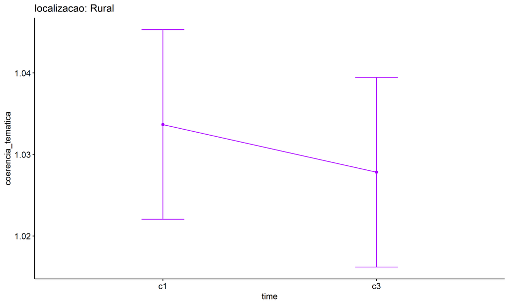

```r
emms.gg <- emms[which(emms$localizacao == "Rural"),]
if (nrow(emms.gg) > 0)
  ggline(emms.gg, x = "time", y = "emmean", color = "#AA00FF", ylab = "coerencia_tematica") +
    geom_errorbar(aes(ymin = conf.low, ymax = conf.high),
                  width = 0.2, color = "#AA00FF") +
    stat_pvalue_manual(
      add_xy_position(pwc[which(pwc$localizacao == "Rural"),],
                      x = "time", fun = "mean_se"),
      hide.ns = T, color = "#AA00FF", tip.length = F) +
    labs(title = "localizacao: Rural")+
    theme(legend.text = element_blank())
```

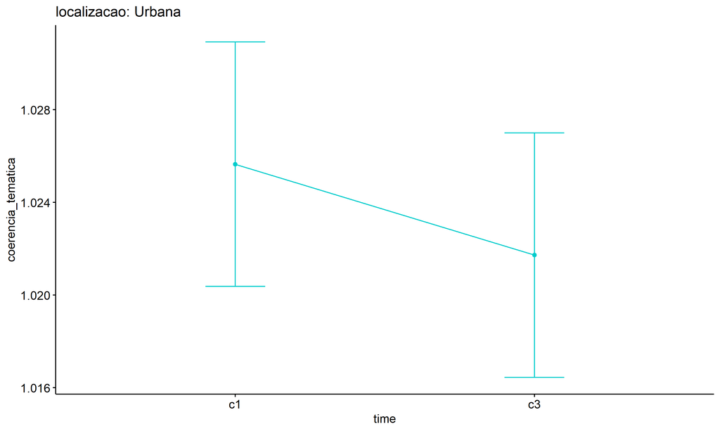

```r
emms.gg <- emms[which(emms$localizacao == "Urbana"),]
if (nrow(emms.gg) > 0)
  ggline(emms.gg, x = "time", y = "emmean", color = "#00CCCC", ylab = "coerencia_tematica") +
    geom_errorbar(aes(ymin = conf.low, ymax = conf.high),
                  width = 0.2, color = "#00CCCC") +
    stat_pvalue_manual(
      add_xy_position(pwc[which(pwc$localizacao == "Urbana"),],
                      x = "time", fun = "mean_se"),
      hide.ns = T, color = "#00CCCC", tip.length = F) +
    labs(title = "localizacao: Urbana")+
    theme(legend.text = element_blank())
```

## PairWise Computation after removing non.normal data

```r
if (length(non.ids) > 0)
  (pwc2 <- ldat2 %>% group_by(time) %>%
     emmeans_test(coerencia_tematica ~ localizacao, detailed = T, p.adjust.method = "bonferroni"))
```

```r
if (length(non.ids) > 0)
  (emms2 <- get_emmeans(pwc2))
```

```r
if (length(non.ids) > 0) {
  pwc2 <- add_xy_position(pwc2, x = "time", fun = "mean_se", dodge = 0.25)
  pd2 <- position_dodge(width = 0.25)

  ggline(emms2, x = "time", y = "emmean", color = "localizacao",
         palette = c("#AA00FF","#00CCCC"),
         position = pd, ylab = "coerencia_tematica") +
    geom_errorbar(aes(ymin = conf.low, ymax = conf.high, color = localizacao),
                position = pd, width = 0.2) +
    stat_pvalue_manual(pwc2, hide.ns = T, tip.length = F, linetype = 1)
}
```

```r
if (length(non.ids) > 0)
  (pwc2 <- ldat2 %>% group_by(localizacao) %>%
     emmeans_test(coerencia_tematica ~ time, detailed = T, p.adjust.method = "bonferroni"))
```

```r
if (length(non.ids) > 0)
  (emms2 <- get_emmeans(pwc2))
```

```r
if (length(non.ids) > 0) {
  emms.gg <- emms2[which(emms2$localizacao == "Rural"),]
  if (nrow(emms.gg) > 0)
    ggline(emms.gg, x = "time", y = "emmean", color = "#AA00FF", ylab = "coerencia_tematica") +
    geom_errorbar(aes(ymin = conf.low, ymax = conf.high),
                  width = 0.2, color = "#AA00FF") +
    stat_pvalue_manual(
      add_xy_position(pwc[which(pwc$localizacao == "Rural"),],
                      x = "time", fun = "mean_se"),
      hide.ns = T, color = "#AA00FF", tip.length = F) +
    labs(title = "localizacao: Rural") +
    theme(legend.text = element_blank())
}
```

```r
if (length(non.ids) > 0) {
  emms.gg <- emms2[which(emms2$localizacao == "Urbana"),]
  if (nrow(emms.gg) > 0)
    ggline(emms.gg, x = "time", y = "emmean", color = "#00CCCC", ylab = "coerencia_tematica") +
    geom_errorbar(aes(ymin = conf.low, ymax = conf.high),
                  width = 0.2, color = "#00CCCC") +
    stat_pvalue_manual(
      add_xy_position(pwc[which(pwc$localizacao == "Urbana"),],
                      x = "time", fun = "mean_se"),
      hide.ns = T, color = "#00CCCC", tip.length = F) +
    labs(title = "localizacao: Urbana") +
    theme(legend.text = element_blank())
}
```

# ANOVA: coerencia_tematica ~ time*regiao + Error(id/time)

## Data Preparation

```r
data <- edat[,c("aluno_id","regiao","ciclo","coerencia_tematica")]
data <- data[data$ciclo %in% c("Primeiro Ciclo","Terceiro Ciclo"),]
data$ciclo <- factor(data$ciclo, c("Primeiro Ciclo","Terceiro Ciclo"))
data <- unique(data)

wdat <- spread(data, ciclo, coerencia_tematica)
wdat <- wdat[complete.cases(wdat),]
colnames(wdat) <- c("id","regiao","c1","c3")

ldat <- gather(wdat, key = time, value = coerencia_tematica, c1,c3) %>%
  convert_as_factor(id, time)
ldat <- remove_group_data(ldat, "coerencia_tematica", c("time", "regiao"), n.limit = 30)
ldat$regiao <- factor(ldat$regiao, sort(unique(ldat$regiao)))
```

### Check assumptions: Identifying Outliers

```r
outliers <- identify_outliers(group_by(ldat, time, regiao), coerencia_tematica)
(outliers <- outliers[outliers$is.extreme == T,])
```

```
## # A tibble: 248 × 6
##    regiao       time  id                coerencia_tematica is.outlier is.extreme
##    <fct>        <fct> <fct>                          <dbl> <lgl>      <lgl>
##  1 Centro-Oeste c1    bp33CvaJwna4IXIi…                2   TRUE       TRUE
##  2 Centro-Oeste c1    cea1pI9NTEIE2VL4…                1.5 TRUE       TRUE
##  3 Centro-Oeste c1    Hctnx0sTLnQqaq89…                1.5 TRUE       TRUE
##  4 Centro-Oeste c1    IOzFe8bKlKLXC426…                2   TRUE       TRUE
##  5 Centro-Oeste c1    lgbCEakOeFbmDSE4…                2   TRUE       TRUE
##  6 Centro-Oeste c1    lkBCRumBZ1wjJR3v…                2   TRUE       TRUE
##  7 Centro-Oeste c1    neHeiZ9VsUQkSRZb…                2   TRUE       TRUE
##  8 Centro-Oeste c1    ngRhEyo2gYwntjRB…                1.5 TRUE       TRUE
##  9 Centro-Oeste c1    RdZuqHC3xwk8iHKX…                1.5 TRUE       TRUE
## 10 Centro-Oeste c1    rSnjLCmkPTnOf3Vs…                2   TRUE       TRUE
## # ℹ 238 more rows
```

| regiao | time | id | coerencia_tematica | is.outlier | is.extreme |
| --- | --- | --- | --- | --- | --- |
| Centro-Oeste | c1 | bp33CvaJwna4IXIiGfG7 | 2.0 | TRUE | TRUE |
| Centro-Oeste | c1 | cea1pI9NTEIE2VL4YEQj | 1.5 | TRUE | TRUE |
| Centro-Oeste | c1 | Hctnx0sTLnQqaq89jDXi | 1.5 | TRUE | TRUE |
| Centro-Oeste | c1 | IOzFe8bKlKLXC426Bw0D | 2.0 | TRUE | TRUE |
| Centro-Oeste | c1 | lgbCEakOeFbmDSE42Un9 | 2.0 | TRUE | TRUE |
| Centro-Oeste | c1 | lkBCRumBZ1wjJR3vXPdU | 2.0 | TRUE | TRUE |
| Centro-Oeste | c1 | neHeiZ9VsUQkSRZb8fmd | 2.0 | TRUE | TRUE |
| Centro-Oeste | c1 | ngRhEyo2gYwntjRBCaRo | 1.5 | TRUE | TRUE |
| Centro-Oeste | c1 | RdZuqHC3xwk8iHKXl8fD | 1.5 | TRUE | TRUE |
| Centro-Oeste | c1 | rSnjLCmkPTnOf3VsNA3D | 2.0 | TRUE | TRUE |
| Centro-Oeste | c1 | wDahW7PwVLOt1hTIN5AJ | 1.5 | TRUE | TRUE |
| Centro-Oeste | c1 | wUV6meEAahx2LVjX4Ao2 | 2.0 | TRUE | TRUE |
| Centro-Oeste | c1 | WXp6KChtWfwGR4v40naQ | 1.5 | TRUE | TRUE |
| Centro-Oeste | c1 | y73LnoGw0PXnuMfR76vZ | 2.0 | TRUE | TRUE |
| Centro-Oeste | c1 | yqyZiP5lTzS4QJWcdjAQ | 1.5 | TRUE | TRUE |
| Nordeste | c1 | 4QkqTlalDsL8IX5Fvsb1 | 1.5 | TRUE | TRUE |
| Nordeste | c1 | A9RUkyTkFXi5lp8ryfZ7 | 2.0 | TRUE | TRUE |
| Nordeste | c1 | cBj30f2ggO0OB96Qa2LS | 1.5 | TRUE | TRUE |
| Nordeste | c1 | col2IMV8zL43sh3escHr | 2.0 | TRUE | TRUE |
| Nordeste | c1 | ctt3C145LmF65O0UFPuM | 1.5 | TRUE | TRUE |
| Nordeste | c1 | eDDthAP6dWERQriBPjXp | 1.5 | TRUE | TRUE |
| Nordeste | c1 | fSeGvYUypBxsn9UAjp8k | 1.5 | TRUE | TRUE |
| Nordeste | c1 | gcimPrBiERP821CKxZgH | 2.0 | TRUE | TRUE |
| Nordeste | c1 | gDRGUsOBQicWdVKdqivA | 1.5 | TRUE | TRUE |
| Nordeste | c1 | GgNJ908EEM577taK2rcX | 1.5 | TRUE | TRUE |
| Nordeste | c1 | gLaZ7sLAnxfq8N5xhMue | 1.5 | TRUE | TRUE |
| Nordeste | c1 | GlJgaFJ0J70UlvV58ITK | 1.5 | TRUE | TRUE |
| Nordeste | c1 | gW6zQXU87OM6vElD5www | 1.5 | TRUE | TRUE |
| Nordeste | c1 | HbX9wIM2m5EDRXj1cGIG | 2.0 | TRUE | TRUE |
| Nordeste | c1 | HgGRdu7lniMmL2jzkEXF | 1.5 | TRUE | TRUE |

[output cut: 218 more lines]

### Check assumptions: Normality Test

```r
(normality.df <- normality.test.per.groups(ldat, "coerencia_tematica", c("time", "regiao")))
```

```
##                   var           variable time       regiao    n skewness
## 1  coerencia_tematica coerencia_tematica   c1 Centro-Oeste  288 0.000000
## 2  coerencia_tematica coerencia_tematica   c1     Nordeste 1287 0.000000
## 3  coerencia_tematica coerencia_tematica   c1        Norte  249 0.000000
## 4  coerencia_tematica coerencia_tematica   c1      Sudeste 2097 8.665337
## 5  coerencia_tematica coerencia_tematica   c1          Sul   76 0.000000
## 6  coerencia_tematica coerencia_tematica   c3 Centro-Oeste  288 0.000000
## 7  coerencia_tematica coerencia_tematica   c3     Nordeste 1287 8.979149
## 8  coerencia_tematica coerencia_tematica   c3        Norte  249 6.706551
## 9  coerencia_tematica coerencia_tematica   c3      Sudeste 2097 9.005941
## 10 coerencia_tematica coerencia_tematica   c3          Sul   76 0.000000
##     kurtosis symmetry statistic     method p p.signif normality
## 1    0.00000 few data        NA       <NA> 1     <NA>        NO
## 2    0.00000 few data        NA       <NA> 1     <NA>        NO
## 3    0.00000 few data        NA       <NA> 1     <NA>        NO
## 4   93.91764       NO 3045.7502 D'Agostino 0     ****         -
## 5    0.00000 few data        NA       <NA> 1     <NA>        NO
## 6    0.00000 few data        NA       <NA> 1     <NA>        NO
## 7  102.74318       NO 1935.1226 D'Agostino 0     ****         -
## 8   57.03280       NO  355.8509 D'Agostino 0     ****         -
## 9   88.47035       NO 3091.1896 D'Agostino 0     ****         -
## 10   0.00000 few data        NA       <NA> 1     <NA>        NO
```

| var | variable | time | regiao | n | skewness | kurtosis | symmetry | statistic | method | p | p.signif | normality |
| --- | --- | --- | --- | --- | --- | --- | --- | --- | --- | --- | --- | --- |
| coerencia_tematica | coerencia_tematica | c1 | Centro-Oeste | 288 | 0.000 | 0.000 | few data | NA | NA | 1 | NA | NO |
| coerencia_tematica | coerencia_tematica | c1 | Nordeste | 1287 | 0.000 | 0.000 | few data | NA | NA | 1 | NA | NO |
| coerencia_tematica | coerencia_tematica | c1 | Norte | 249 | 0.000 | 0.000 | few data | NA | NA | 1 | NA | NO |
| coerencia_tematica | coerencia_tematica | c1 | Sudeste | 2097 | 8.665 | 93.918 | NO | 3045.750 | D’Agostino | 0 | **** | - |
| coerencia_tematica | coerencia_tematica | c1 | Sul | 76 | 0.000 | 0.000 | few data | NA | NA | 1 | NA | NO |
| coerencia_tematica | coerencia_tematica | c3 | Centro-Oeste | 288 | 0.000 | 0.000 | few data | NA | NA | 1 | NA | NO |
| coerencia_tematica | coerencia_tematica | c3 | Nordeste | 1287 | 8.979 | 102.743 | NO | 1935.123 | D’Agostino | 0 | **** | - |
| coerencia_tematica | coerencia_tematica | c3 | Norte | 249 | 6.707 | 57.033 | NO | 355.851 | D’Agostino | 0 | **** | - |
| coerencia_tematica | coerencia_tematica | c3 | Sudeste | 2097 | 9.006 | 88.470 | NO | 3091.190 | D’Agostino | 0 | **** | - |
| coerencia_tematica | coerencia_tematica | c3 | Sul | 76 | 0.000 | 0.000 | few data | NA | NA | 1 | NA | NO |

```r
(non.ids <- unique(do.call(
  c, lapply(which(normality.df$normality == 'NO'), FUN = function(i) {
  idx = which(ldat$time == normality.df$time[i] &
                ldat$regiao == normality.df$regiao[i])
  getNonNormal(ldat$"coerencia_tematica"[idx], ldat$id[idx])
}))))
```

```r
if (length(non.ids) > 0)
  ldat2 <- ldat[!ldat$id %in% non.ids,]
```

### Summary Statistics

```r
(sdat <- ldat %>% group_by(time, regiao) %>%
   get_summary_stats(coerencia_tematica, type = "mean_sd"))
```

```
## # A tibble: 10 × 6
##    regiao       time  variable               n  mean    sd
##    <fct>        <fct> <fct>              <dbl> <dbl> <dbl>
##  1 Centro-Oeste c1    coerencia_tematica   288  1.04 0.18
##  2 Nordeste     c1    coerencia_tematica  1287  1.04 0.159
##  3 Norte        c1    coerencia_tematica   249  1.03 0.148
##  4 Sudeste      c1    coerencia_tematica  2097  1.02 0.132
##  5 Sul          c1    coerencia_tematica    76  1    0
##  6 Centro-Oeste c3    coerencia_tematica   288  1.04 0.187
##  7 Nordeste     c3    coerencia_tematica  1287  1.03 0.195
##  8 Norte        c3    coerencia_tematica   249  1.05 0.273
##  9 Sudeste      c3    coerencia_tematica  2097  1.01 0.12
## 10 Sul          c3    coerencia_tematica    76  1    0
```

| regiao | time | variable | n | mean | sd |
| --- | --- | --- | --- | --- | --- |
| Centro-Oeste | c1 | coerencia_tematica | 288 | 1.040 | 0.180 |
| Nordeste | c1 | coerencia_tematica | 1287 | 1.036 | 0.159 |
| Norte | c1 | coerencia_tematica | 249 | 1.034 | 0.148 |
| Sudeste | c1 | coerencia_tematica | 2097 | 1.020 | 0.132 |
| Sul | c1 | coerencia_tematica | 76 | 1.000 | 0.000 |
| Centro-Oeste | c3 | coerencia_tematica | 288 | 1.038 | 0.187 |
| Nordeste | c3 | coerencia_tematica | 1287 | 1.028 | 0.195 |
| Norte | c3 | coerencia_tematica | 249 | 1.054 | 0.273 |
| Sudeste | c3 | coerencia_tematica | 2097 | 1.014 | 0.120 |
| Sul | c3 | coerencia_tematica | 76 | 1.000 | 0.000 |

```r
if (length(non.ids) > 0)
  (sdat <- ldat2 %>% group_by(time, regiao) %>%
      get_summary_stats(coerencia_tematica, type = "mean_sd"))
```

| regiao | time | variable | n | mean | sd |
| --- | --- | --- | --- | --- | --- |
| Centro-Oeste | c1 | coerencia_tematica | 288 | 1.040 | 0.180 |
| Nordeste | c1 | coerencia_tematica | 1287 | 1.036 | 0.159 |
| Norte | c1 | coerencia_tematica | 249 | 1.034 | 0.148 |
| Sudeste | c1 | coerencia_tematica | 2097 | 1.020 | 0.132 |
| Sul | c1 | coerencia_tematica | 76 | 1.000 | 0.000 |
| Centro-Oeste | c3 | coerencia_tematica | 288 | 1.038 | 0.187 |
| Nordeste | c3 | coerencia_tematica | 1287 | 1.028 | 0.195 |
| Norte | c3 | coerencia_tematica | 249 | 1.054 | 0.273 |
| Sudeste | c3 | coerencia_tematica | 2097 | 1.014 | 0.120 |
| Sul | c3 | coerencia_tematica | 76 | 1.000 | 0.000 |

## ANOVA Computation

```r
(res.aov <- anova_test(ldat, dv = coerencia_tematica, wid = id, between = regiao, within = time))
```

```
## ANOVA Table (type III tests)
##
##        Effect DFn  DFd     F        p p<.05      ges
## 1      regiao   4 3992 7.995 2.04e-06     * 4.00e-03
## 2        time   1 3992 0.027 8.70e-01       3.28e-06
## 3 regiao:time   4 3992 0.889 4.69e-01       4.39e-04
```

## ANOVA Computation after removing non.normal data

```r
if (length(non.ids) > 0)
  (res.aov2 <- anova_test(ldat2, dv = coerencia_tematica, wid = id, between = regiao , within = time))
```

## PairWise Computation

```r
(pwc <- ldat %>% group_by(time) %>%
   emmeans_test(coerencia_tematica ~ regiao, detailed = T, p.adjust.method = "bonferroni"))
```

| time | term | .y. | group1 | group2 | null.value | estimate | se | df | conf.low | conf.high | statistic | p | p.adj | p.adj.signif |
| --- | --- | --- | --- | --- | --- | --- | --- | --- | --- | --- | --- | --- | --- | --- |
| c1 | regiao | coerencia_tematica | Centro | Oeste | 0 | 0.004 | 0.010 | 7984 | -0.016 | 0.024 | 0.415 | 0.678 | 1.000 | ns |
| c1 | regiao | coerencia_tematica | Centro | Oeste | 0 | 0.006 | 0.013 | 7984 | -0.020 | 0.032 | 0.433 | 0.665 | 1.000 | ns |
| c1 | regiao | coerencia_tematica | Centro | Oeste | 0 | 0.020 | 0.010 | 7984 | 0.001 | 0.039 | 2.047 | 0.041 | 0.407 | ns |
| c1 | regiao | coerencia_tematica | Centro | Oeste | 0 | 0.040 | 0.020 | 7984 | 0.001 | 0.079 | 2.001 | 0.045 | 0.454 | ns |
| c1 | regiao | coerencia_tematica | Nordeste | Norte | 0 | 0.002 | 0.011 | 7984 | -0.019 | 0.023 | 0.150 | 0.881 | 1.000 | ns |
| c1 | regiao | coerencia_tematica | Nordeste | Sudeste | 0 | 0.016 | 0.005 | 7984 | 0.005 | 0.026 | 2.868 | 0.004 | 0.041 | * |
| c1 | regiao | coerencia_tematica | Nordeste | Sul | 0 | 0.036 | 0.018 | 7984 | 0.000 | 0.072 | 1.957 | 0.050 | 0.504 | ns |
| c1 | regiao | coerencia_tematica | Norte | Sudeste | 0 | 0.014 | 0.010 | 7984 | -0.006 | 0.034 | 1.360 | 0.174 | 1.000 | ns |
| c1 | regiao | coerencia_tematica | Norte | Sul | 0 | 0.034 | 0.020 | 7984 | -0.006 | 0.074 | 1.683 | 0.092 | 0.923 | ns |
| c1 | regiao | coerencia_tematica | Sudeste | Sul | 0 | 0.020 | 0.018 | 7984 | -0.015 | 0.055 | 1.109 | 0.268 | 1.000 | ns |
| c3 | regiao | coerencia_tematica | Centro | Oeste | 0 | 0.010 | 0.010 | 7984 | -0.010 | 0.030 | 0.975 | 0.330 | 1.000 | ns |
| c3 | regiao | coerencia_tematica | Centro | Oeste | 0 | -0.016 | 0.013 | 7984 | -0.042 | 0.010 | -1.197 | 0.231 | 1.000 | ns |
| c3 | regiao | coerencia_tematica | Centro | Oeste | 0 | 0.024 | 0.010 | 7984 | 0.005 | 0.043 | 2.457 | 0.014 | 0.140 | ns |
| c3 | regiao | coerencia_tematica | Centro | Oeste | 0 | 0.038 | 0.020 | 7984 | -0.001 | 0.077 | 1.914 | 0.056 | 0.556 | ns |
| c3 | regiao | coerencia_tematica | Nordeste | Norte | 0 | -0.026 | 0.011 | 7984 | -0.047 | -0.005 | -2.414 | 0.016 | 0.158 | ns |
| c3 | regiao | coerencia_tematica | Nordeste | Sudeste | 0 | 0.014 | 0.005 | 7984 | 0.003 | 0.025 | 2.565 | 0.010 | 0.103 | ns |
| c3 | regiao | coerencia_tematica | Nordeste | Sul | 0 | 0.028 | 0.018 | 7984 | -0.007 | 0.064 | 1.553 | 0.121 | 1.000 | ns |
| c3 | regiao | coerencia_tematica | Norte | Sudeste | 0 | 0.040 | 0.010 | 7984 | 0.020 | 0.060 | 3.848 | 0.000 | 0.001 | ** |
| c3 | regiao | coerencia_tematica | Norte | Sul | 0 | 0.054 | 0.020 | 7984 | 0.014 | 0.094 | 2.674 | 0.008 | 0.075 | ns |
| c3 | regiao | coerencia_tematica | Sudeste | Sul | 0 | 0.014 | 0.018 | 7984 | -0.021 | 0.050 | 0.792 | 0.428 | 1.000 | ns |

```r
(emms <- get_emmeans(pwc))
```

```
## # A tibble: 10 × 8
##    time  regiao       emmean      se    df conf.low conf.high method
##    <fct> <fct>         <dbl>   <dbl> <dbl>    <dbl>     <dbl> <chr>
##  1 c1    Centro-Oeste   1.04 0.00912  7984    1.02       1.06 Emmeans test
##  2 c1    Nordeste       1.04 0.00431  7984    1.03       1.04 Emmeans test
##  3 c1    Norte          1.03 0.00981  7984    1.01       1.05 Emmeans test
##  4 c1    Sudeste        1.02 0.00338  7984    1.01       1.03 Emmeans test
##  5 c1    Sul            1.00 0.0177   7984    0.965      1.03 Emmeans test
##  6 c3    Centro-Oeste   1.04 0.00912  7984    1.02       1.06 Emmeans test
##  7 c3    Nordeste       1.03 0.00431  7984    1.02       1.04 Emmeans test
##  8 c3    Norte          1.05 0.00981  7984    1.03       1.07 Emmeans test
##  9 c3    Sudeste        1.01 0.00338  7984    1.01       1.02 Emmeans test
## 10 c3    Sul            1.00 0.0177   7984    0.965      1.03 Emmeans test
```

| time | regiao | emmean | se | df | conf.low | conf.high | method |
| --- | --- | --- | --- | --- | --- | --- | --- |
| c1 | Centro-Oeste | 1.040 | 0.009 | 7984 | 1.022 | 1.058 | Emmeans test |
| c1 | Nordeste | 1.036 | 0.004 | 7984 | 1.027 | 1.044 | Emmeans test |
| c1 | Norte | 1.034 | 0.010 | 7984 | 1.015 | 1.053 | Emmeans test |
| c1 | Sudeste | 1.020 | 0.003 | 7984 | 1.013 | 1.027 | Emmeans test |
| c1 | Sul | 1.000 | 0.018 | 7984 | 0.965 | 1.035 | Emmeans test |
| c3 | Centro-Oeste | 1.038 | 0.009 | 7984 | 1.020 | 1.056 | Emmeans test |
| c3 | Nordeste | 1.028 | 0.004 | 7984 | 1.020 | 1.037 | Emmeans test |
| c3 | Norte | 1.054 | 0.010 | 7984 | 1.035 | 1.073 | Emmeans test |
| c3 | Sudeste | 1.014 | 0.003 | 7984 | 1.008 | 1.021 | Emmeans test |
| c3 | Sul | 1.000 | 0.018 | 7984 | 0.965 | 1.035 | Emmeans test |

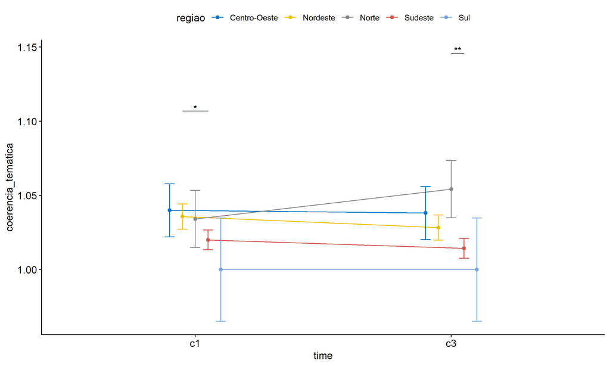

```r
pwc <- add_xy_position(pwc, x = "time", fun = "mean_se", dodge = 0.25)
pd <- position_dodge(width = 0.25)
ggline(emms, x = "time", y = "emmean", color = "regiao",
       palette = c("#0073C2FF","#EFC000FF","#868686FF","#CD534CFF","#7AA6DCFF"),
       position = pd, ylab = "coerencia_tematica") +
  geom_errorbar(aes(ymin = conf.low, ymax = conf.high, color = regiao),
                position = pd, width = 0.2) +
  stat_pvalue_manual(pwc, hide.ns = T, tip.length = F, linetype = 1)
```

```r
(pwc <- ldat %>% group_by(regiao) %>%
    emmeans_test(coerencia_tematica ~ time, detailed = T, p.adjust.method = "bonferroni"))
```

```
## # A tibble: 5 × 15
##   regiao   term  .y.   group1 group2 null.value  estimate      se    df conf.low
## * <fct>    <chr> <chr> <chr>  <chr>       <dbl>     <dbl>   <dbl> <dbl>    <dbl>
## 1 Centro-… time  coer… c1     c3              0  1.74e- 3 0.0129   7984 -0.0235
## 2 Nordeste time  coer… c1     c3              0  7.38e- 3 0.00610  7984 -0.00458
## 3 Norte    time  coer… c1     c3              0 -2.01e- 2 0.0139   7984 -0.0473
## 4 Sudeste  time  coer… c1     c3              0  5.72e- 3 0.00478  7984 -0.00364
## 5 Sul      time  coer… c1     c3              0  9.15e-17 0.0251   7984 -0.0492
## # ℹ 5 more variables: conf.high <dbl>, statistic <dbl>, p <dbl>, p.adj <dbl>,
## #   p.adj.signif <chr>
```

| regiao | term | .y. | group1 | group2 | null.value | estimate | se | df | conf.low | conf.high | statistic | p | p.adj | p.adj.signif |
| --- | --- | --- | --- | --- | --- | --- | --- | --- | --- | --- | --- | --- | --- | --- |
| Centro-Oeste | time | coerencia_tematica | c1 | c3 | 0 | 0.002 | 0.013 | 7984 | -0.024 | 0.027 | 0.135 | 0.893 | 0.893 | ns |
| Nordeste | time | coerencia_tematica | c1 | c3 | 0 | 0.007 | 0.006 | 7984 | -0.005 | 0.019 | 1.210 | 0.226 | 0.226 | ns |
| Norte | time | coerencia_tematica | c1 | c3 | 0 | -0.020 | 0.014 | 7984 | -0.047 | 0.007 | -1.448 | 0.148 | 0.148 | ns |
| Sudeste | time | coerencia_tematica | c1 | c3 | 0 | 0.006 | 0.005 | 7984 | -0.004 | 0.015 | 1.198 | 0.231 | 0.231 | ns |
| Sul | time | coerencia_tematica | c1 | c3 | 0 | 0.000 | 0.025 | 7984 | -0.049 | 0.049 | 0.000 | 1.000 | 1.000 | ns |

```r
(emms <- get_emmeans(pwc))
```

```
## # A tibble: 10 × 8
##    regiao       time  emmean      se    df conf.low conf.high method
##    <fct>        <fct>  <dbl>   <dbl> <dbl>    <dbl>     <dbl> <chr>
##  1 Centro-Oeste c1      1.04 0.00912  7984    1.02       1.06 Emmeans test
##  2 Centro-Oeste c3      1.04 0.00912  7984    1.02       1.06 Emmeans test
##  3 Nordeste     c1      1.04 0.00431  7984    1.03       1.04 Emmeans test
##  4 Nordeste     c3      1.03 0.00431  7984    1.02       1.04 Emmeans test
##  5 Norte        c1      1.03 0.00981  7984    1.01       1.05 Emmeans test
##  6 Norte        c3      1.05 0.00981  7984    1.03       1.07 Emmeans test
##  7 Sudeste      c1      1.02 0.00338  7984    1.01       1.03 Emmeans test
##  8 Sudeste      c3      1.01 0.00338  7984    1.01       1.02 Emmeans test
##  9 Sul          c1      1.00 0.0177   7984    0.965      1.03 Emmeans test
## 10 Sul          c3      1.00 0.0177   7984    0.965      1.03 Emmeans test
```

| regiao | time | emmean | se | df | conf.low | conf.high | method |
| --- | --- | --- | --- | --- | --- | --- | --- |
| Centro-Oeste | c1 | 1.040 | 0.009 | 7984 | 1.022 | 1.058 | Emmeans test |
| Centro-Oeste | c3 | 1.038 | 0.009 | 7984 | 1.020 | 1.056 | Emmeans test |
| Nordeste | c1 | 1.036 | 0.004 | 7984 | 1.027 | 1.044 | Emmeans test |
| Nordeste | c3 | 1.028 | 0.004 | 7984 | 1.020 | 1.037 | Emmeans test |
| Norte | c1 | 1.034 | 0.010 | 7984 | 1.015 | 1.053 | Emmeans test |
| Norte | c3 | 1.054 | 0.010 | 7984 | 1.035 | 1.073 | Emmeans test |
| Sudeste | c1 | 1.020 | 0.003 | 7984 | 1.013 | 1.027 | Emmeans test |
| Sudeste | c3 | 1.014 | 0.003 | 7984 | 1.008 | 1.021 | Emmeans test |
| Sul | c1 | 1.000 | 0.018 | 7984 | 0.965 | 1.035 | Emmeans test |
| Sul | c3 | 1.000 | 0.018 | 7984 | 0.965 | 1.035 | Emmeans test |

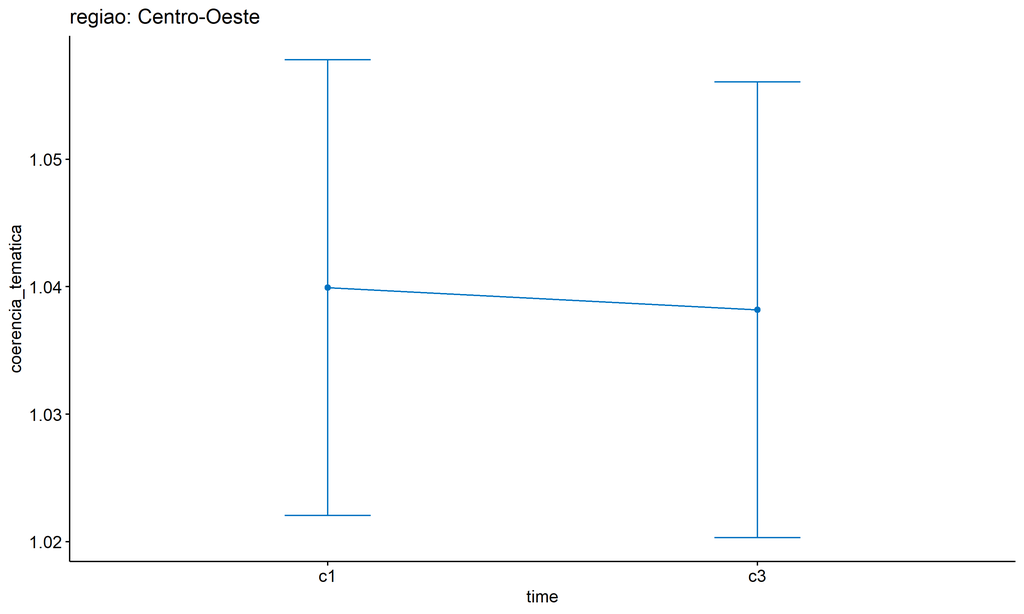

```r
emms.gg <- emms[which(emms$regiao == "Centro-Oeste"),]
if (nrow(emms.gg) > 0)
  ggline(emms.gg, x = "time", y = "emmean", color = "#0073C2FF", ylab = "coerencia_tematica") +
    geom_errorbar(aes(ymin = conf.low, ymax = conf.high),
                  width = 0.2, color = "#0073C2FF") +
    stat_pvalue_manual(
      add_xy_position(pwc[which(pwc$regiao == "Centro-Oeste"),],
                      x = "time", fun = "mean_se"),
      hide.ns = T, color = "#0073C2FF", tip.length = F) +
    labs(title = "regiao: Centro-Oeste")+
    theme(legend.text = element_blank())
```

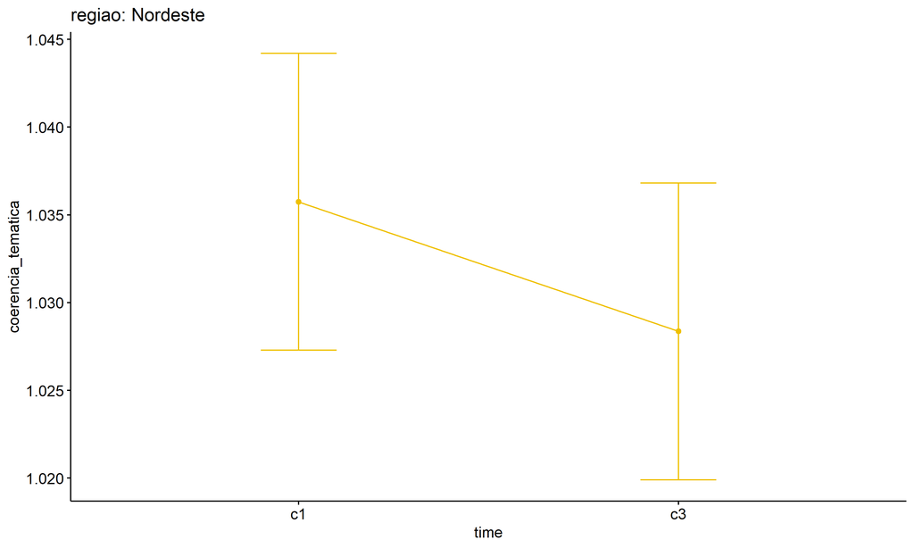

```r
emms.gg <- emms[which(emms$regiao == "Nordeste"),]
if (nrow(emms.gg) > 0)
  ggline(emms.gg, x = "time", y = "emmean", color = "#EFC000FF", ylab = "coerencia_tematica") +
    geom_errorbar(aes(ymin = conf.low, ymax = conf.high),
                  width = 0.2, color = "#EFC000FF") +
    stat_pvalue_manual(
      add_xy_position(pwc[which(pwc$regiao == "Nordeste"),],
                      x = "time", fun = "mean_se"),
      hide.ns = T, color = "#EFC000FF", tip.length = F) +
    labs(title = "regiao: Nordeste")+
    theme(legend.text = element_blank())
```